# chapter4

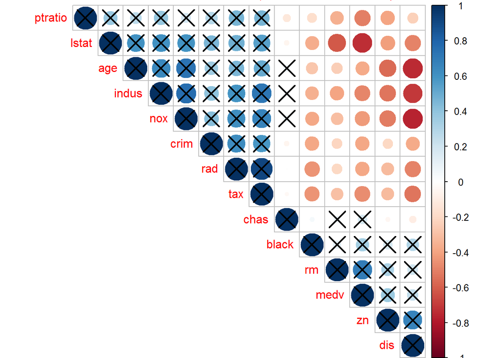

```r
corrplot(bos, type="upper", order="hclust",
         p.mat = bos)
```

Next, I scaled the Boston data. The Scaling was done by substracting the column means from the corresponding columns and dividing the difference with standard deviation. As a result of the scaling all variable means were set to zero. Scaling the data frame changes the data type to matrix for which reason I had to change it back to data frame after the scaling was done.

```r
bostonZ <- scale(Boston)
summary(bostonZ)
```

```
##       crim                 zn               indus
##  Min.   :-0.419367   Min.   :-0.48724   Min.   :-1.5563
##  1st Qu.:-0.410563   1st Qu.:-0.48724   1st Qu.:-0.8668
##  Median :-0.390280   Median :-0.48724   Median :-0.2109
##  Mean   : 0.000000   Mean   : 0.00000   Mean   : 0.0000
##  3rd Qu.: 0.007389   3rd Qu.: 0.04872   3rd Qu.: 1.0150
##  Max.   : 9.924110   Max.   : 3.80047   Max.   : 2.4202
##       chas              nox                rm               age
##  Min.   :-0.2723   Min.   :-1.4644   Min.   :-3.8764   Min.   :-2.3331
##  1st Qu.:-0.2723   1st Qu.:-0.9121   1st Qu.:-0.5681   1st Qu.:-0.8366
##  Median :-0.2723   Median :-0.1441   Median :-0.1084   Median : 0.3171
##  Mean   : 0.0000   Mean   : 0.0000   Mean   : 0.0000   Mean   : 0.0000
##  3rd Qu.:-0.2723   3rd Qu.: 0.5981   3rd Qu.: 0.4823   3rd Qu.: 0.9059
##  Max.   : 3.6648   Max.   : 2.7296   Max.   : 3.5515   Max.   : 1.1164
##       dis               rad               tax             ptratio
##  Min.   :-1.2658   Min.   :-0.9819   Min.   :-1.3127   Min.   :-2.7047
##  1st Qu.:-0.8049   1st Qu.:-0.6373   1st Qu.:-0.7668   1st Qu.:-0.4876
##  Median :-0.2790   Median :-0.5225   Median :-0.4642   Median : 0.2746
##  Mean   : 0.0000   Mean   : 0.0000   Mean   : 0.0000   Mean   : 0.0000
##  3rd Qu.: 0.6617   3rd Qu.: 1.6596   3rd Qu.: 1.5294   3rd Qu.: 0.8058
##  Max.   : 3.9566   Max.   : 1.6596   Max.   : 1.7964   Max.   : 1.6372
##      black             lstat              medv
##  Min.   :-3.9033   Min.   :-1.5296   Min.   :-1.9063
##  1st Qu.: 0.2049   1st Qu.:-0.7986   1st Qu.:-0.5989
##  Median : 0.3808   Median :-0.1811   Median :-0.1449
##  Mean   : 0.0000   Mean   : 0.0000   Mean   : 0.0000
##  3rd Qu.: 0.4332   3rd Qu.: 0.6024   3rd Qu.: 0.2683
##  Max.   : 0.4406   Max.   : 3.5453   Max.   : 2.9865
```

```r
bostonZ <- as.data.frame(bostonZ)
```

The crim variabe was then categorized cutting it to quantiles.

```r
scaled_crim <- bostonZ$crim
# creatING a quantile vector of crim
bins <- quantile(scaled_crim)
# setting the quantiles as the break points and creating a categorical crime variable
crime <- cut(scaled_crim, breaks = bins, include.lowest = TRUE, label = c("low", "med_low", "med_high", "high"))
# remove the crim
bostonZ <- dplyr::select(bostonZ, -crim)
# add the crime
bostonZ <- data.frame(bostonZ, crime)
#
```

After creating the categorical crime variable I splitted the scaled Boston data to two sets: training set and test set. The training set consisted of 80% randomly chosen observations whereas the test set consisted of the remaining 20% of the rows.

```r
# defining the number of rows in the scaled Boston dataset
n <- nrow(bostonZ)

# randomly choosing 80% of the rows
ind <- sample(n,  size = n * 0.8)

# creating a train set
train <- bostonZ[ind,]

# creating a test set
test <- bostonZ[-ind,]

# saving the correct classes from test data to a separate vector
correct_classes <- test$crime

# removing the crime variable from test data
test <- dplyr::select(test, -crime)
```

The training set was used for creating a linear discriminant analysis (LDA) functions that could be later utilized to cluster new set of observations to correct classes of crime. The purpose of linear discriminant analysis was to find the linear combinations of the continuous variables (13 variables from the boston data) giving the best possible separation between the groups (crime quantiles). The maximum number of estimated discriminant functions is usually defined as the amount of groups (crime quantiles) subtracted by 1 (in this case 3 discriminant functions).

```r
# Running linear discriminant analysis (lda) on the train data crime set as the target
lda.fit <- lda(crime ~ ., data = train)
lda.fit
```

```
## Call:
## lda(crime ~ ., data = train)
##
## Prior probabilities of groups:
##       low   med_low  med_high      high
## 0.2400990 0.2475248 0.2524752 0.2599010
##
## Group means:
##                  zn      indus         chas        nox          rm
## low       0.9924631 -0.9296921 -0.069385757 -0.8635769  0.45934982
## med_low  -0.0931993 -0.2535115  0.003267949 -0.5481302 -0.09496550
## med_high -0.3762641  0.2113288  0.152260173  0.3974868  0.08810606
## high     -0.4872402  1.0170492 -0.047351911  1.0763418 -0.40572947
##                 age        dis        rad        tax      ptratio
## low      -0.8721546  0.9161366 -0.6977144 -0.7433282 -0.428032764
## med_low  -0.3103465  0.2507859 -0.5546415 -0.4432089  0.009915447
## med_high  0.3458713 -0.3643313 -0.3986301 -0.2825461 -0.253886871
## high      0.7956459 -0.8429261  1.6388211  1.5145512  0.781583385
##               black       lstat        medv
## low       0.3796342 -0.78272047  0.52764007
## med_low   0.3076402 -0.18552749  0.02263687
## med_high  0.1131089  0.01288811  0.16144655
## high     -0.8207068  0.89777017 -0.64631593
##
## Coefficients of linear discriminants:
##                 LD1          LD2         LD3
## zn       0.10104175  0.838293509 -0.77348481
## indus   -0.00529245 -0.302142271  0.20833092
## chas    -0.08160482  0.009331703  0.15726701
## nox      0.45157820 -0.621858086 -1.64435481
## rm      -0.10642646 -0.069047324 -0.11897984
## age      0.25902605 -0.180443765 -0.08916468
## dis     -0.02246132 -0.264237075 -0.22529099
## rad      3.00465349  0.910154909 -0.09722186
## tax     -0.04668267 -0.058261920  0.65639686
## ptratio  0.13623593  0.094317705 -0.20071222
## black   -0.13817871 -0.017094071  0.10673215
## lstat    0.22941473 -0.273920826  0.21737066
## medv     0.22805532 -0.365039788 -0.34047981
##
## Proportion of trace:
##    LD1    LD2    LD3
## 0.9480 0.0381 0.0139
```

when creating the biplot of the model also the so-called biplot arrows were added. A separate function was used for adding the arrows to the biplot. As revealed by the biplot, the **** first discriminant function (LD1) separates high crime class from other classes but doesn’t perfectly separate low, med_low and med_high. LD2 is unable to separate the high from other classes but performs relatively well in separating low from med_high. There is, however, no perfect dimension to separate the med_low and med_high levels.

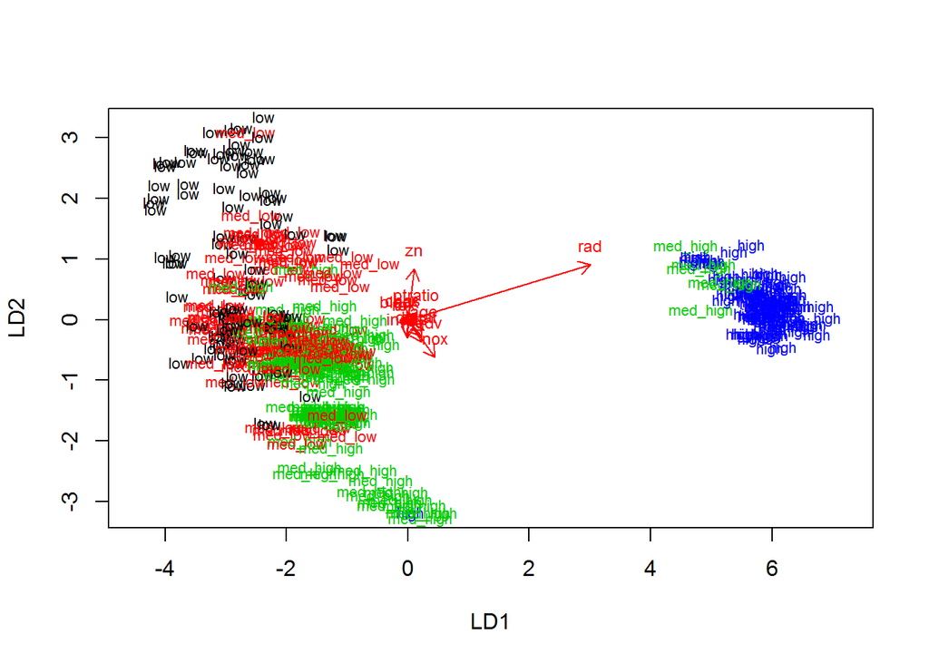

```r
# the function for lda biplot arrows
lda.arrows <- function(x, myscale = 1, arrow_heads = 0.1, color = "red", tex = 0.75, choices = c(1,2)){
  heads <- coef(x)
  arrows(x0 = 0, y0 = 0,
         x1 = myscale * heads[,choices[1]],
         y1 = myscale * heads[,choices[2]], col=color, length = arrow_heads)
  text(myscale * heads[,choices], labels = row.names(heads),
       cex = tex, col=color, pos=3)
}

# target classes as numeric
classes <- as.numeric(train$crime)

# plot the lda results
plot(lda.fit, dimen = 2, col = classes, pch = classes)
lda.arrows(lda.fit, myscale = 1)
```

```r
# using the model to predict crime classes in the test data
lda.pred <- predict(lda.fit, newdata = test)

# cross tabulate the results
table(correct = correct_classes, predicted = lda.pred$class)
```

```
##           predicted
## correct    low med_low med_high high
##   low       16      14        0    0
##   med_low    3      20        3    0
##   med_high   0      11       13    0
##   high       0       0        0   22
```

After clustering the Boston data with the LDA, I moved on to k-means method. K-means is an unsupervised clustering method, that is it does not require training. Consecuently, it does not know the correct amount of clusters. For that reason, I had to first run the kmeans model several times for different amount of clusters (1:10). To see, which cluster amount works best, I calculated the total within subject squares of each solution and plotted that against the cluster number (x-axis).

```r
data('Boston')

BostonScaled <- scale(Boston)

set.seed(123)

# euclidean distance matrix
dist_eu <- dist(BostonScaled)
summary(dist_eu)
```

```
##    Min. 1st Qu.  Median    Mean 3rd Qu.    Max.
##  0.1343  3.4620  4.8240  4.9110  6.1860 14.4000
```